# MaL - Matice II.

Jan Schubert, Ivan Petrusek

V tomto cviceni budeme pokracovat v operacich s maticemi. Nejdrive si ukazeme (pripomeneme), jak vypocitat system linernich rovnic. Ve cviceni 1 jsme pocitali, zda je soustava vektoru linearne zavisla/nezavisla. Tehdy jsme resili soustavu rovnic podobnou teto:

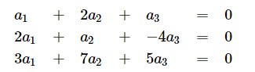

Zdroj: Matematika.cz

Je to specificky pripad, kdy resime, zda se tato soustava rovna 0. Stejne tak muzeme resit, zda se urcita soustava rovna necemu jinemu. Obecne se to da zapsat jako:

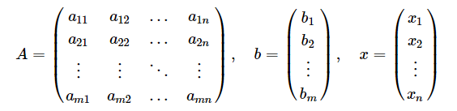

Zdroj: Matematika.cz

My uz vime, ze k reseni takove soustavy se da pouzit funkce `solve`. Zkuste tedy vyresit tento priklad.

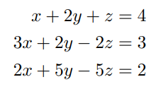

```r
# nejprve si prepiseme matici.
M <- matrix(c(1,2,1,3,2,-2,2,5,-5), byrow = TRUE, ncol = 3, nrow = 3)

#definujeme vysledek na prave strane rovnice
b = c(4,3,2)

#pomoci funkce solve vyresime x,y a z
reseni <- solve(M, b)
print(reseni)
```

```
## [1] 1 1 1
```

Nyni zkusme dosadit do rovnice, zda odpovida vysledku

```r
M %*% reseni
```

```
##      [,1]
## [1,]    4
## [2,]    3
## [3,]    2
```

Muzeme take vyuzit logicky operator `==` a porovnat, zda se reseni rovna b

```r
M %*% reseni == b
```

```
##      [,1]
## [1,] TRUE
## [2,] TRUE
## [3,] TRUE
```

Dale se pustime do vypoctu inverzni matice. Nejcasteji pouzivanou metodou je Gaussova-Jordanova metoda eliminace, jejiz princip spociva v tom, ze si k matici M vytvorime jednotkovou matici a upravujeme ji spolecne s matici M dokud na leve strane nemame jednotkovou matici. Zkusme vypocitat inverzni matici k teto matici

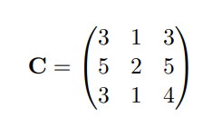

```r
#nejprve si vytvorime matici C
C <- matrix(c(3,1,3,5,2,5,3,1,4), byrow = TRUE, ncol = 3, nrow = 3)

# k ni si vytvorime jednotkovou matici
I3 <- matrix(c(1,0,0,0,1,0,0,0,1), nrow = 3, ncol = 3, byrow = TRUE)

# ted obe matice sloucime tak, abychom meli matici C na leve strane a jednotkovou matici na prave strane
CI <- cbind(C, I3)
print(CI)
```

```
##      [,1] [,2] [,3] [,4] [,5] [,6]
## [1,]    3    1    3    1    0    0
## [2,]    5    2    5    0    1    0
## [3,]    3    1    4    0    0    1
```

```r
# 1. SLOUPEC
## zacneme s tim, ze prvni radek vydeline 3
CI[1, ] <- CI[1, ] * 1/3
print(CI)
```

```
##      [,1]      [,2] [,3]      [,4] [,5] [,6]
## [1,]    1 0.3333333    1 0.3333333    0    0
## [2,]    5 2.0000000    5 0.0000000    1    0
## [3,]    3 1.0000000    4 0.0000000    0    1
```

```r
## nyni se budeme snazit eliminovat prvni sloupec. Cilem je nim v prnim sloupci 1,0,0
### prvni radek vynasobime -5 a pricteme v druhemu radku
CI[2, ] <- CI[1, ] * -5 + CI[2, ]
print(CI)
```

```
##      [,1]      [,2] [,3]       [,4] [,5] [,6]
## [1,]    1 0.3333333    1  0.3333333    0    0
## [2,]    0 0.3333333    0 -1.6666667    1    0
## [3,]    3 1.0000000    4  0.0000000    0    1
```

```r
### treti radek prvni sloupec ilinujeme podobne tak ze vynasobime prvni radek -3 a pricteme ke tretimu
CI[3, ] <- CI[1, ] * -3 + CI[3, ]
print(CI)
```

```
##      [,1]      [,2] [,3]       [,4] [,5] [,6]
## [1,]    1 0.3333333    1  0.3333333    0    0
## [2,]    0 0.3333333    0 -1.6666667    1    0
## [3,]    0 0.0000000    1 -1.0000000    0    1
```

```r
### Poznamka: Vidime, ze na tretim radku (v prvnich trech sloupcech) uz mame k dispozici pozadovany treti radek jednotkove matice. Jinymi slovy, treti radek je "hotovy" - nemusime uz delat zadne upravy na tretim radku

# 2. SLOUPEC
## druhy sloupec uz mame skoro hotovy. Schazi nam pouze premenit 1/3 na 1 v druhem radku a na 0 v prvnim. Nejdrive upravime druhy radek tak, aby byl rovny 1. To udelame tak, ze ho vynasobime 3
CI[2, ] <- CI[2, ] * 3
print(CI)
```

```
##      [,1]      [,2] [,3]       [,4] [,5] [,6]
## [1,]    1 0.3333333    1  0.3333333    0    0
## [2,]    0 1.0000000    0 -5.0000000    3    0
## [3,]    0 0.0000000    1 -1.0000000    0    1
```

```r
## Eliminace druheho sloupce >>> vidime, ze musime eliminovat pouze 1/3 v prvnim radku. To udelame tak,  ze druhy radek vynasobime -1/3 a pricteme
CI[1, ] <- CI[2, ] * -1/3 + CI[1, ]
print(CI)
```

```
##      [,1]          [,2] [,3] [,4] [,5] [,6]
## [1,]    1 -1.665335e-16    1    2   -1    0
## [2,]    0  1.000000e+00    0   -5    3    0
## [3,]    0  0.000000e+00    1   -1    0    1
```

```r
# 3. SLOUPEC
## Nakonec uz nam pouze zbyva odstranit z prvniho radku ve trenim slopci 1. To udelame tak, ze odecteme treti radek * -1 od prvniho
CI[1, ] <- CI[3, ] * -1 + CI[1, ]
print(CI)
```

```
##      [,1]          [,2] [,3] [,4] [,5] [,6]
## [1,]    1 -1.665335e-16    0    3   -1   -1
## [2,]    0  1.000000e+00    0   -5    3    0
## [3,]    0  0.000000e+00    1   -1    0    1
```

```r
# ZKOUSKA SPRAVNOSTI
# ziskali jsme tak na prave strane inverzni matici k puvodni matici. Muzeme si ji ulozit do objektu C_inverse

C_inverse <- CI[, 4:6]
### Zkouska spravnosti: vynasobime matici C a inverzni matici k matici C
# >>> pokud byla inverzni matice vypocitana spravne, tak vysledkem maticoveho soucinu je jednotkova matice
C %*% C_inverse
```

```
##      [,1] [,2] [,3]
## [1,]    1    0    0
## [2,]    0    1    0
## [3,]    0    0    1
```

Celou tuto operaci muzeme provest pomoci funkce `solve`. Zkusme tedy nyni provest stejnou operaci, ale pomoci `solve`.

```r
solve(C)
```

```
##      [,1] [,2]          [,3]
## [1,]    3   -1 -1.000000e+00
## [2,]   -5    3 -2.220446e-15
## [3,]   -1    0  1.000000e+00
```

Jako posledni vypocitame nasledujici priklad:

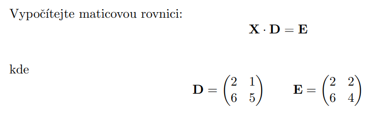

```r
# definujme si zname matice
D <- matrix(c(2, 1, 6, 5), nrow = 2, ncol = 2, byrow = TRUE)
E <- matrix(c(2, 2, 6, 4), nrow = 2, ncol = 2, byrow = TRUE)

### Podrobne vysvetleny vecny postup (samotny vypocet v R je velmi jednoduchy):
# 1.) Obe matice jsou ctvercove >>> matice X bude taky ctvercova (2x2)
# 2.) Potrebujeme matici D odstranit z leve strany rovnice a dostat ji na pravou stranu rovnice.
# Vime pritom, ze pokud vynasobime matici D inverzni matici k matici D, tak vysledkem maticoveho soucinu je jednotkova matice.
# Obe strany maticove rovnice tudiz musime ZPRAVA vynasobit D-1 (inverzni matici k matici D):   XDD-1 = ED-1
# Levou stranu zjednodusime na XI (protoze DD-1 = I)
# Z prednasky vime, ze pokud vynasobime jakoukoli ctvercovou matici jednotkovou matici, tak vysledkem maticoveho soucinu je puvodni ctvercova matice
# >>> Levou stranu muzeme zjednodusit na X (XI = IX = X)
# 3.) Resenim maticove rovnice je tedy: X = ED-1
# V R vypocitame inverzni matici k matici D s vyuzitim funkce solve (inverzni matici tady neukladam do objektu)
X <- E %*% solve(D)
print(X)
```

```
##      [,1] [,2]
## [1,] -0.5  0.5
## [2,]  1.5  0.5
```

```r
# zkouska spravnosti
X %*% D
```

```
##      [,1] [,2]
## [1,]    2    2
## [2,]    6    4
```

```r
X %*% D == E
```

```
##      [,1] [,2]
## [1,] TRUE TRUE
## [2,] TRUE TRUE
```

Tolik k dnesnim matematickym cvicenim. Nyni si prestavime dalsi koncept z R. Je to pravdepodobne vubec nejpouzivanejsi objekt, s kterym se v R setkate a rika se mu `data.frame` (datova matice). `data.frame` je velmi podobny objektu `matrix`. Jeho hlavnim rozdilem je to, ze jeho promenne nemusi byt stejne tridy. Muzeme tedy kombinovat ruzne tridy bez toho, aniz bychom zmenili tridy ostatnich promennych.

Vratme se k nasemu prikladu z minule hodiny.

```r
rok_narozeni <- c(2000, 1999, 2000, 2001)
vyska <- c(167, 176, 189, 181)
jmeno <- c("Petr", "Jakub", "Pavel", "Jindra")
```

`data.frame` vytvorime pomoci funckce `data.frame()`. Zkuste se podivat na jeji napovedu `?data.frame`.

```r
df <- data.frame(rok_narozeni, vyska, jmeno)
```

Na `data.frame` muzete pouzit vsechny funkce, ktere jsme si ukazali na prikladu matic. Tedy:

```r
dim(df)
```

```
## [1] 4 3
```

```r
class(df)
```

```
## [1] "data.frame"
```

```r
str(df)
```

```
## 'data.frame':    4 obs. of  3 variables:
##  $ rok_narozeni: num  2000 1999 2000 2001
##  $ vyska       : num  167 176 189 181
##  $ jmeno       : Factor w/ 4 levels "Jakub","Jindra",..: 4 1 3 2
```

```r
df[1, ]
```

```
##   rok_narozeni vyska jmeno
## 1         2000   167  Petr
```

```r
df[c(1,4), ]
```

```
##   rok_narozeni vyska  jmeno
## 1         2000   167   Petr
## 4         2001   181 Jindra
```

```r
df[, "jmeno"]
```

```
## [1] Petr   Jakub  Pavel  Jindra
## Levels: Jakub Jindra Pavel Petr
```

```r
df[, c(1:2)]
```

```
##   rok_narozeni vyska
## 1         2000   167
## 2         1999   176
## 3         2000   189
## 4         2001   181
```

U objektu tridy `data.frame` muzeme sloupce datove matice subsettovat jejich jmeny s vyuzitim operatoru `$`.

```r
df$vyska
```

```
## [1] 167 176 189 181
```

Stejne tak muzeme operator `$` pouzit k prirazeni novych promennych

```r
df$vek <- 2020 - df$rok_narozeni
print(df)
```

```
##   rok_narozeni vyska  jmeno vek
## 1         2000   167   Petr  20
## 2         1999   176  Jakub  21
## 3         2000   189  Pavel  20
## 4         2001   181 Jindra  19
```